# Homework 5

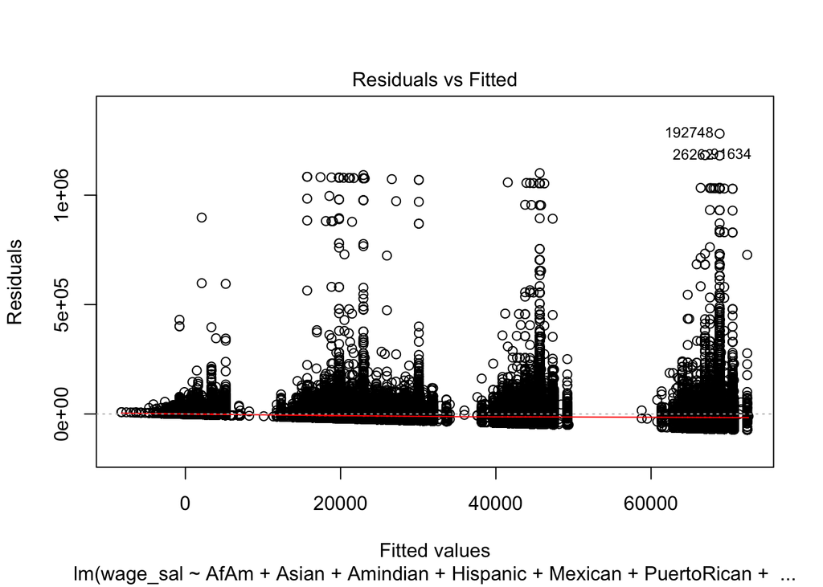

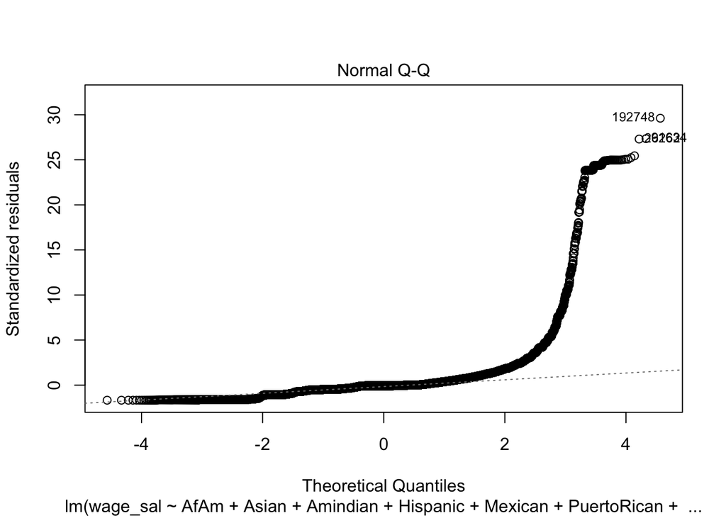

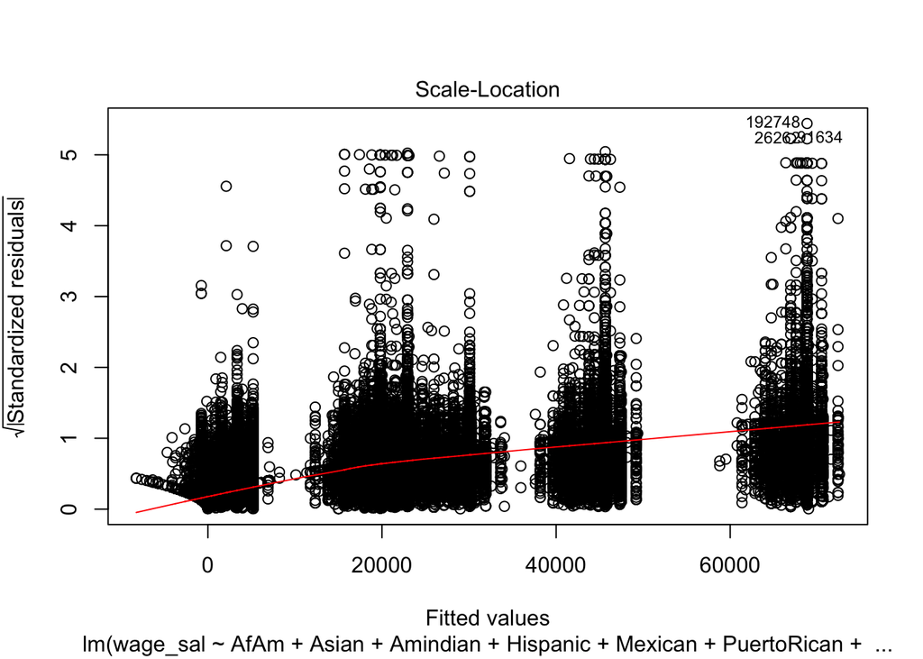

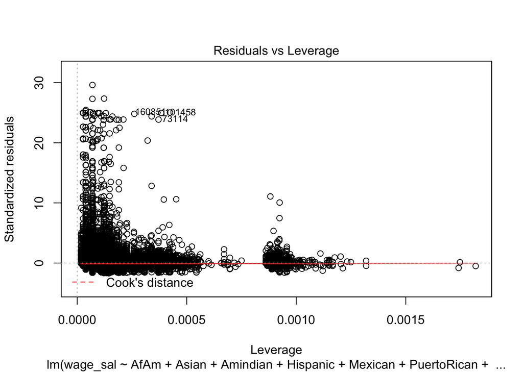

```r
plot(model4)
```

This regression showed an even higher level of confidence that being Cuban can decrease your salary but also indicated an interesting concept that having Mexican heritage can help increase your salary while being Hispanic can lower it. Another interesting finding was that being an immigrant actually increased your salary by $3,500 while being a second generation immigrant lowers it by $1,900! The only explanation I can think of for this phenominom is that first generation immigrants possibly have a different work ethic as they build a new life, different federal programs to help them find better work when they arrive, and possibly even the current government standards for receiving green cards/citizenship for those with degrees or skills in areas that already provide higher wages (doctors, scientists, etc). Whereas the children of these immigrants do not meet these same standards.